```r
library(dplyr)
library(ggplot2)
```

# Exercise 1: Discrete random variable

#### The probability distribution function of a discrete variable k is given by the following:

$$ p(k) = \begin{equation} \begin{cases} \frac{k}{15} \hspace{1 cm} \text{with} \hspace{5 mm}\text{k} = 1, 2, 3, 4, ...\\ 0 \hspace{1.2 cm} \text{otherwise} \end{cases} \end{equation} $$

#### 1.1) Define the Probability Distrubution its relative Cumulative Distribution

```r
maximum = 5
pdf = double(maximum)
cdf = pdf
x_axis = 1:maximum
for (i in 1:maximum) {
    pdf[i] = i/15
    for (j in 1:i){
        cdf[i] = cdf[i] + pdf[j]
    }
}
```

#### 1.2) Plotting the CDF and PDF

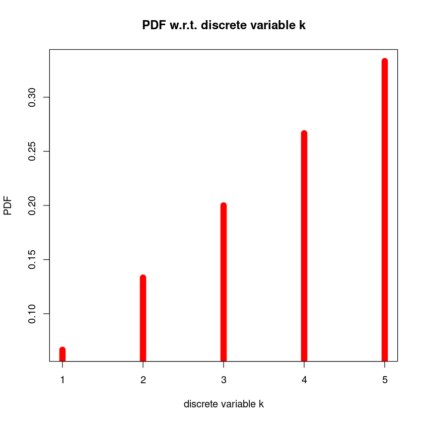

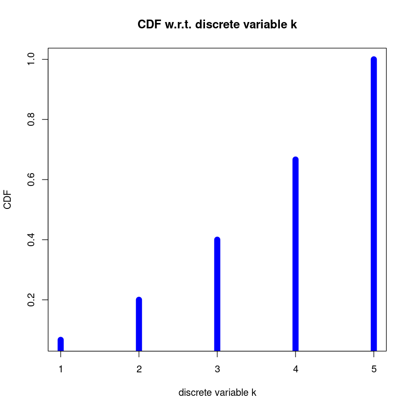

```r
plot(x_axis, pdf, type="h", lwd=10, col="red", xlab="discrete variable k", ylab="PDF", main="PDF w.r.t. discrete variable k")
plot(x_axis, cdf, type="h", lwd=10, col="blue", xlab="discrete variable k", ylab="CDF", main="CDF w.r.t. discrete variable k")
```

#### 1.3) Computing the mean value and variance of the distribution

```r
mean = 0
variance = 0
for (i in 1:maximum){
    mean = mean + pdf[i]*i
    variance = variance + pdf[i]*i**2
}
variance = variance - mean**2


cat("Mean value of distribution is", mean, "\n")
cat("Variance of distribution is", variance)
```

```
Mean value of distribution is 3.666667
Variance of distribution is 1.555556
```

#### 1.4) Computing the expected value of $E[k(6-k)]$

```r
expected_value = 0
for (i in 1:maximum){
    expected_value = expected_value + pdf[i]*i*6 - pdf[i]*i**2
}

cat("The expected value of E[k(6-k)] is:", expected_value)
```

```
The expected value of E[k(6-k)] is: 7
```

#### 1.5) Function that selects random numbers from the PDF

```r
generator = function(pdf, number){ # Takes the discrete distribution "pdf" attributes and outputs "number" data such distributted
    maximum = length(pdf)
    cdf = double(length(pdf))

    for (i in 1:maximum) {
        pdf[i] = i/15
        for (j in 1:i){
            cdf[i] = cdf[i] + pdf[j]
        }
    }

    output = double(number)
    u = runif(number)

    for (j in 1:number) {
        entered = TRUE
        for (k in 1:maximum){
            if (u[j] < cdf[k]){
                if (entered == TRUE) {
                    output[j] = k
                    entered = FALSE
                }
            }
        }
    }

    return(output)
}
```

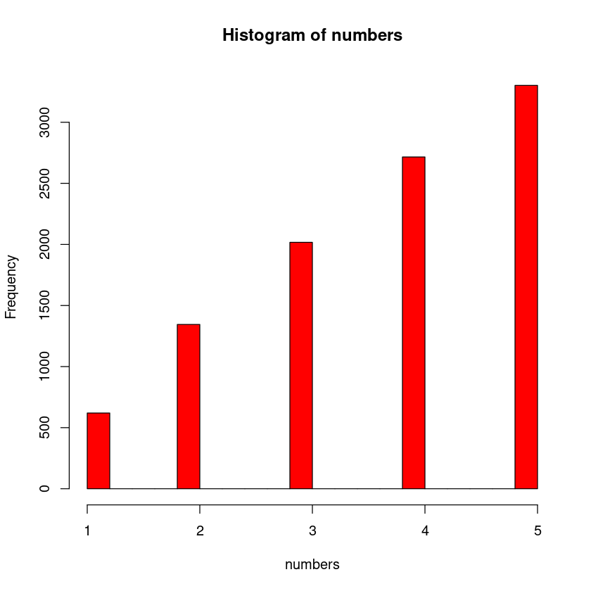

```r
numbers = generator(pdf, 10000)

hist(numbers, col = "red")
# numbers
```

# Exercise 2: Continuous Random Variable

#### The triangular distribution, in the interval (a, b), is given by the following:

$$ f(X) = \begin{equation} \begin{cases} \frac{2(x-a)}{(b-a)(c-a)} \hspace{1 cm} a \leq x < c \\ \frac{2(b-x)}{(b-a)(b-c)} \hspace{1 cm} c < x \leq b \\ 0 \hspace{2.1 cm} \text{otherwise} \end{cases} \end{equation} $$

#### 2.1) Plotting the triangular distribution in the interval (a, b)

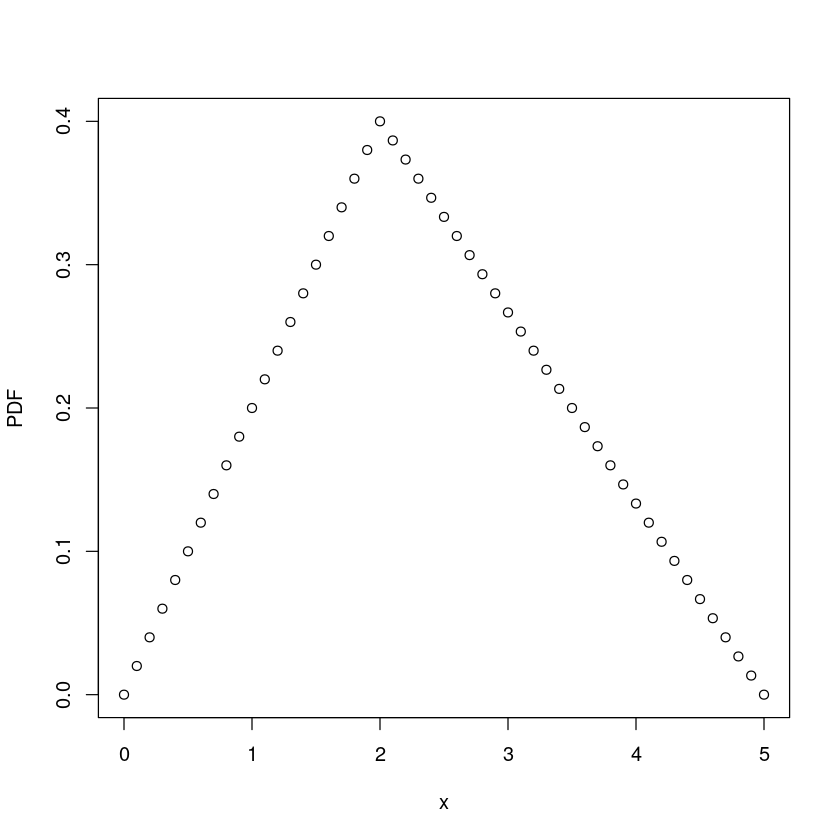

```r
triangular = function(x, a, b, c){
    out = 0
    if ((x < c) && (x > a)) {
        out = 2*(x-a)/((b-a)*(c-a))
    } else if ((x >= c) && (x < b)) {
        out = 2*(b-x)/((b-a)*(b-c))
    }
    return(out)
}

# for what I did, the code is able to reproduce a triangular distribution
a = 0
b = 5
c = 2

x = seq(a, b, by=0.1)
triangolare = double(length(x))
for (l in 1:length(x)){
    triangolare[l] = triangular(x[l], a, b, c)
}
plot(x, triangolare, ylab="PDF")
```

I plot also the cumulative distribution

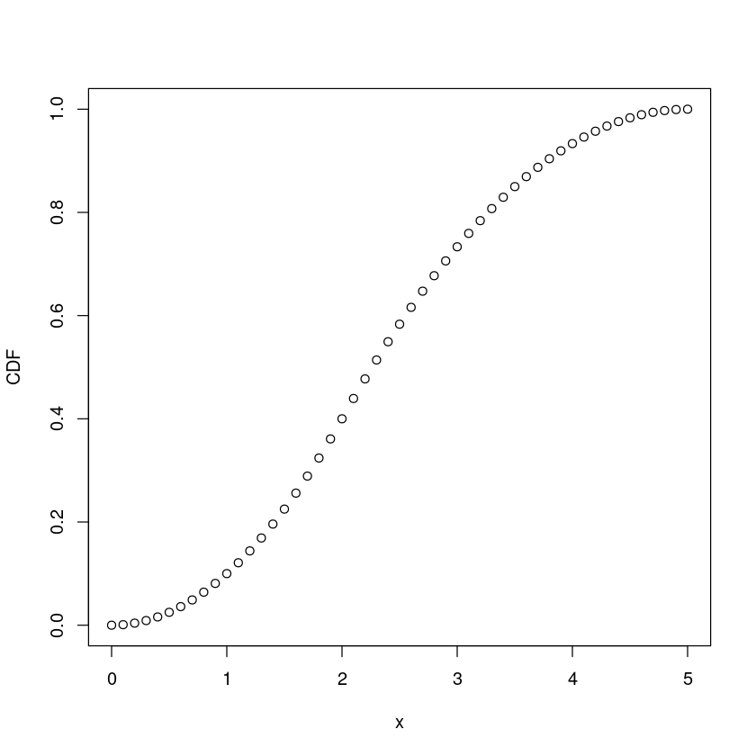

```r
cdf = function (x, a, b, c) {
    out = 0
    if ((x < c) && (x > a)) {
        out = x*(x-2*a)/((b-a)*(c-a)) + a**2/((b-a)*(c-a))
    } else if ((x >= c) && (x < b)) {
        out = x*(2*b-x)/((b-a)*(b-c)) - c*(2*b-c)/((b-a)*(b-c)) + c*(c-2*a)/((b-a)*(c-a)) + a**2/((b-a)*(c-a))
    } else if (x >= b) {
        out = 1
    }
    return(out)
}

x = seq(a, b, by=0.1)
triangolare = double(length(x))
for (l in 1:length(x)){
    triangolare[l] = cdf(x[l], a, b, c)
}
plot(x, triangolare, ylab="CDF")
```

#### 2.2) Function able to generate random numbers according to the triangular distribution

```r
pdf_generator = function (number, a, b, c) { # Returns a vector containing points that follow the PDF distribution
    u = runif(number)
    out = double(number)

    # Check if the data is in the first or second curve:
    for (i in 1:number) {
        if (u[i] < ((c-a)/(b-a))) {
            out[i] = a + sqrt(u[i]*(b-a)*(c-a)) # Formula of the CDF found by hand
        } else {
            out[i] = b - sqrt((1 - u[i])*(b-a)*(b-c)) # Formula of the CDF found by hand
        }
    }
    return(out)
}
```

#### 2.3) Generate $10^4$ numbers and prove that it is a triangulat dristribution

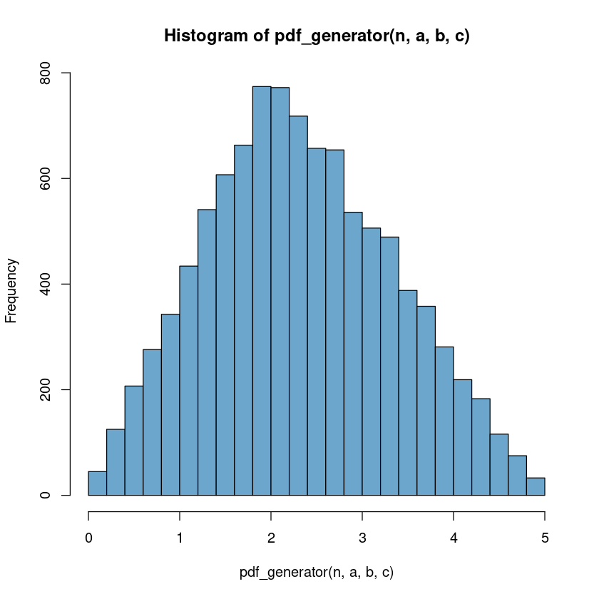

```r
n = as.integer(1e4)
hist(pdf_generator(n, a, b, c), col = 'skyblue3', breaks = 20)
```

# Exercise 3) Waiting time at the doctor

#### The waiting time, in minutes, at the doctor’s is about 30 minutes, and the distribution follows an exponential pdf with rate 1/30

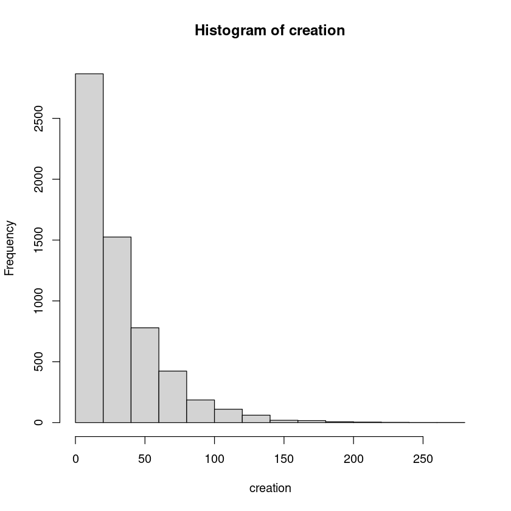

```r
exponential_cdf = function(number, lambda=1/30) {
    u = runif(number)
    out = double(number)

    for (i in 1:number) {
        # out[i] = i
        out[i] = - (log(1 - u[i]))/lambda
    }
    return(out)
}

n = 6000
lambda = 1/30

# plot(exponential_cdf(n, lambda))
creation = exponential_cdf(n, lambda)
hist(creation)
```

#### 3.2) What is the probability that a person will wait for less than 12 minutes ?

```r
p_less = function(limit) {
    p_less = 0
    for (i in 1:n) {
        if (creation[i]<limit) {
            p_less = p_less + 1
        }
    }
    return(p_less)
}

limit = 12
p_less = p_less(limit)

cat("The probability of waiting less than", limit, "minutes is", p_less/n, "\n")
cat("The expected value from theory is 1 - e^(-12/30) = 0.3296799")
```

```
The probability of waiting less than 12 minutes is 0.3281667
The expected value from theory is 1 - e^(-12/30) = 0.3296799
```

#### 3.3) Evaluate the average waiting time from the simulated data and compare it with the expected value

```r
mean = mean(creation)

cat("The mean value in the generated data is", mean, "\n")
cat("The expected value from theory is 1/lambda = 30")
```

```
The mean value in the generated data is 30.17619
The expected value from theory is 1/lambda = 30
```

#### 3.4) What is the probability for waiting more than one hour before being received?

```r
p_greater = function(limit) {
    p_greater = 0
    for (i in 1:n) {
        if (creation[i] > limit) {
            p_greater = p_greater + 1
        }
    }
    return(p_greater)
}

limit = 60
p_greater = p_greater(limit)

cat("The probability of waiting less than", limit, "minutes is", p_greater/n, "\n")
cat("The expected value from theory is 1 - e^(-60/30) = 0.1353352")
```

[output not shown]

# Exercise 4) Multiple choices exams

#### The final exam of a course is given to the students in the format of a multiple choice written test: for each questions there are five possible alternatives. A student either knows the answer, or selects randomly the answer among the five possible choices. Assuming p = 0.7 the probability that the student knows the answer, once a correct answer is given, what it the probability that the student really knew the correct answer ?

```r
total_answers = 1e4
number_questions = 5
p = 0.7

answers_from_probability = function(number, p) {
    answers = double(number)
    u = runif(number)

    for (i in 1:number) {
        if (u[i] < as.double(p)) {
            answers[i] = 1
        } else if (runif(1) < as.double(1/number_questions)) {
            answers[i] = 2
        }
    }
    return(answers)
}


answers = answers_from_probability(total_answers, p)

percentage = 0
number_positive = 0
for (i in 1:total_answers) {
    if(answers[i] > 0) {
        number_positive = number_positive + 1
        if (answers[i] < 2) {
            percentage = percentage + 1
        }
    }
}
percentage = (percentage/number_positive)

cat("The probability for a right answer to have been known is", percentage, "\n")
cat("The theorical probability is 0.7/0.76 = 0.9210526")
```

```
The probability for a right answer to have been known is 0.9277763
The theorical probability is 0.7/0.76 = 0.9210526
```

# Exercise 5) Waiting time

#### Starting from 5:00 in the morning, every half an hour there is a train from Milano Centrale to Roma Termini. We assume there is always an available seat on a train leaving from Milano. Assuming a person arrives at a random time between 10:45 and 11:45 and compute the probability that she has to wait

#### 1) at most 10 minutes

```r
# Creating a uniform distribution for an hour
random_n = 1000
date_init = "2023-06-04 10:45:00"
date_fin  = "2023-06-04 11:45:00"
minutes = difftime(date_fin, date_init, units="sec")

# Create a uniform time distribution in the interval
distribution_time = as.POSIXct(date_init) + runif(n=random_n, min=0, max=minutes)

# Define the accepted arrival deadlines
difference_up   = 10
difference_down = 0
passage_0 = "2023-06-04 10:30:00"
passage_1 = "2023-06-04 11:00:00"
passage_2 = "2023-06-04 11:30:00"
most_10_min_1 = distribution_time[(difftime(distribution_time, passage_1, units="mins") < difference_up) & (difftime(distribution_time, passage_1, units="mins") > difference_down)]
most_10_min_1 = distribution_time[(difftime(distribution_time, passage_2, units="mins") < difference_up) & (difftime(distribution_time, passage_2, units="mins") > difference_down)]

cat("The probability for a person to wait for at most 10 minutes is:", (length(most_10_min_1) + length(most_10_min_2))/random_n, "\n")
cat("The theorical probability is: 0.333")
```

[output not shown]

#### 2) at least 15 minutes

```r
# I use the same time distribution (even though the results will be correlated)
difference_up   = 30
difference_down = 15
least_15_min_1 = distribution_time[(difftime(distribution_time, passage_0, units="mins") < difference_up) & (difftime(distribution_time, passage_0, units="mins") > difference_down)]
least_15_min_2 = distribution_time[(difftime(distribution_time, passage_1, units="mins") < difference_up) & (difftime(distribution_time, passage_1, units="mins") > difference_down)]

cat("The probability for a person to wait for more than 15 minutes is:", (length(least_15_min_1) + length(least_15_min_2))/random_n, "\n")
cat("The theorical probability is: 0.5")
```

```
The probability for a person to wait for more than 15 minutes is: 0.518
The theorical probability is: 0.5
```

#### 3) what is the average time spent waiting?

```r
# Same as before
difference_up   = 30
difference_down = 0

# Slice the time distribution based on the taken train
null_average   = distribution_time[(difftime(distribution_time, passage_0, units="mins") < difference_up) & (difftime(distribution_time, passage_0, units="mins") > difference_down)]
first_average  = distribution_time[(difftime(distribution_time, passage_1, units="mins") < difference_up) & (difftime(distribution_time, passage_1, units="mins") > difference_down)]
second_average = distribution_time[(difftime(distribution_time, passage_2, units="mins") < difference_up) & (difftime(distribution_time, passage_2, units="mins") > difference_down)]

# Evaluate the average as sum divided per the number of attempt
average_time = sum(difftime(null_average, passage_0, units="mins")) + sum(difftime(first_average, passage_1, units="mins")) + sum(difftime(second_average, passage_2, units="mins"))

cat("In order, the waited time for a different train is\n", sum(difftime(null_average, passage_0, units="mins"))/length(null_average),
    "minutes for the one passing at", passage_0, ", then\n", sum(difftime(first_average, passage_1, units="mins"))/length(first_average),
    "minutes for the one passing at", passage_1, "and then\n", sum(difftime(second_average, passage_2, units="mins"))/length(second_average),
    "minutes for the one passing at", passage_2, "\n")

cat("The average time waited is: ", (average_time/random_n), "minutes")
```

```
In order, the waited time for a different train is
 22.43805 minutes for the one passing at 2023-06-04 10:30:00 , then
 14.53428 minutes for the one passing at 2023-06-04 11:00:00 and then
 6.840648 minutes for the one passing at 2023-06-04 11:30:00
The average time waited is:  14.86197 minutes
```

# Exercise 6) stock investmen

#### The annual return rate for a specific stock on the market is a normal variable with a 10% mean and a 12% standard deviation. Mr X decides to buy 200 share of that specific stock at a price of 85 $\text{€}$ per share. What is the probability that after a year his net profit from the investment is at least 800 $\text{€}$? (suppose there are no transaction costs and that there are no annual dividend for the stock)

```r
n_tests = 10000

n_share = 200
price_per_share = 85

annual_return = rnorm(n=n_share*n_tests, mean=0.1, sd=0.12)
increase = annual_return*price_per_share

dim(increase) = c(n_share, n_tests)
interest = double(n_tests)

for (i in 1:n_tests) {
    interest[i] = sum(increase[,i])
}

searched_value = 800
cat("The percentage of having a profit over 800 euros is:", (length(interest[interest > searched_value])/n_tests)*100, "%\n")
```

```
The percentage of having a profit over 800 euros is: 100 %
```